# Insurance Charges Analysis

2025-03-06

data source: https://www.kaggle.com/datasets/mirichoi0218/insurance

```r
# Load Libraries
library(ggplot2)
library(caret)
library(dplyr)
library(MASS)       # Stepwise regression
library(glmnet)     # Lasso and Ridge regression
library(car)        # Model diagnostics
library(corrplot)   # Correlation heatmap
library(interactions) # Visualization of interactions
library(lmtest)
```

# 1.EDA

## 1.1 Load dataset

```r
insurance <- read.csv("/Users/christie/Desktop/project/insurance.csv")
str(insurance)
```

```
## 'data.frame':    1338 obs. of  7 variables:
##  $ age     : int  19 18 28 33 32 31 46 37 37 60 ...
##  $ sex     : chr  "female" "male" "male" "male" ...
##  $ bmi     : num  27.9 33.8 33 22.7 28.9 ...
##  $ children: int  0 1 3 0 0 0 1 3 2 0 ...
##  $ smoker  : chr  "yes" "no" "no" "no" ...
##  $ region  : chr  "southwest" "southeast" "southeast" "northwest" ...
##  $ charges : num  16885 1726 4449 21984 3867 ...
```

```r
summary(insurance)
```

```
##       age            sex                 bmi           children
##  Min.   :18.00   Length:1338        Min.   :15.96   Min.   :0.000
##  1st Qu.:27.00   Class :character   1st Qu.:26.30   1st Qu.:0.000
##  Median :39.00   Mode  :character   Median :30.40   Median :1.000
##  Mean   :39.21                      Mean   :30.66   Mean   :1.095
##  3rd Qu.:51.00                      3rd Qu.:34.69   3rd Qu.:2.000
##  Max.   :64.00                      Max.   :53.13   Max.   :5.000
##     smoker             region             charges
##  Length:1338        Length:1338        Min.   : 1122
##  Class :character   Class :character   1st Qu.: 4740
##  Mode  :character   Mode  :character   Median : 9382
##                                        Mean   :13270
##                                        3rd Qu.:16640
##                                        Max.   :63770
```

## 1.2 Visualize distribution of numeric variables

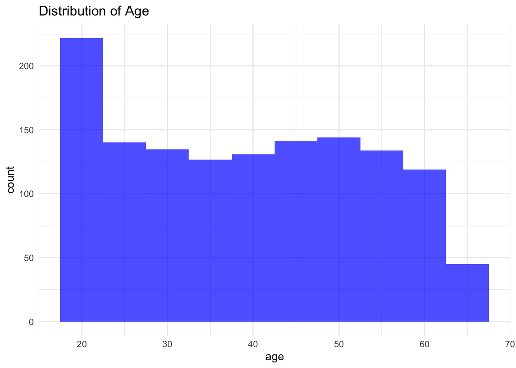

```r
ggplot(insurance, aes(x = age)) + geom_histogram(binwidth = 5, fill = "blue", alpha = 0.7) + theme_minimal() + ggtitle("Distribution of Age")
```

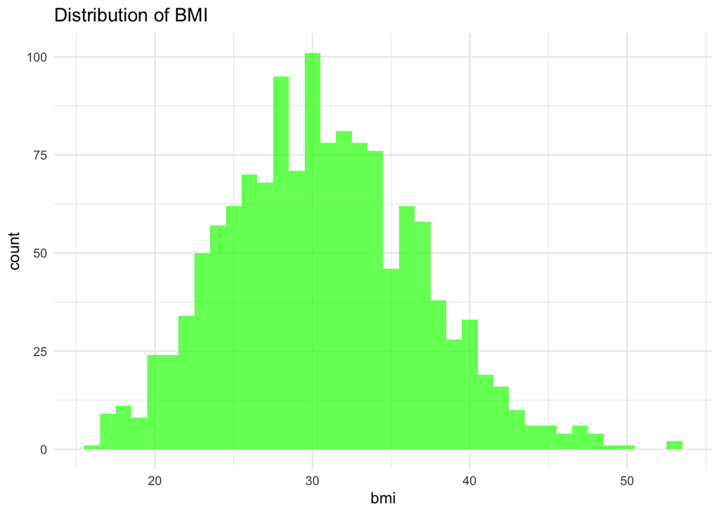

```r
ggplot(insurance, aes(x = bmi)) + geom_histogram(binwidth = 1, fill = "green", alpha = 0.7) + theme_minimal() + ggtitle("Distribution of BMI")
```

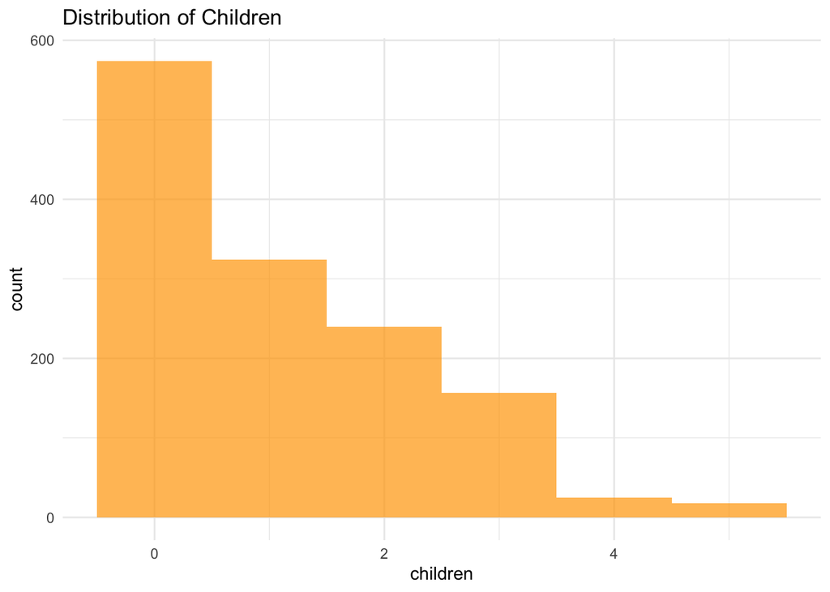

```r
ggplot(insurance, aes(x = children)) + geom_histogram(binwidth = 1, fill = "orange", alpha = 0.7) + theme_minimal() + ggtitle("Distribution of Children")
```

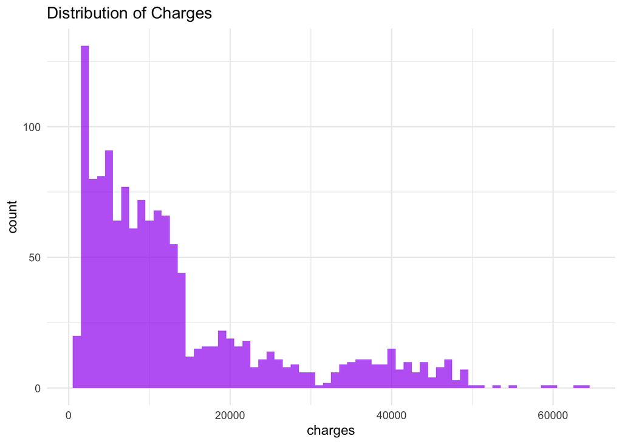

```r
ggplot(insurance, aes(x = charges)) + geom_histogram(binwidth = 1000, fill = "purple", alpha = 0.7) + theme_minimal() + ggtitle("Distribution of Charges")
```

## 1.3 Visualize distribution of categorical variables

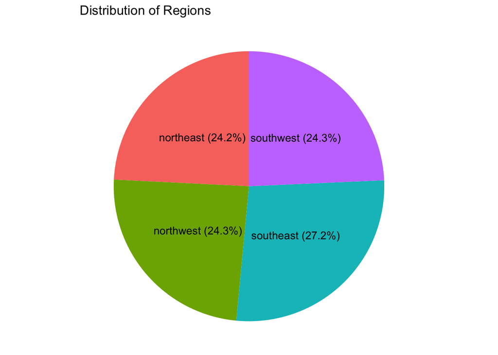

```r
region_data <- insurance %>%
  count(region) %>%
  mutate(perc = n / sum(n) * 100,
         label = paste0(region, " (", round(perc, 1), "%)"))

ggplot(region_data, aes(x = "", y = perc, fill = region)) +
  geom_bar(width = 1, stat = "identity") +
  coord_polar("y") +
  labs(title = "Distribution of Regions", x = NULL, y = NULL) +
  theme_void() +
  geom_text(aes(label = label), position = position_stack(vjust = 0.5)) +
  theme(legend.position = "none")
```

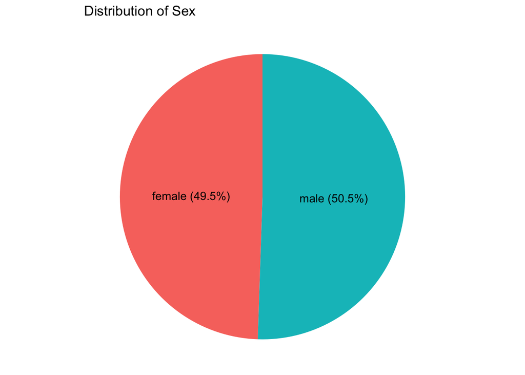

```r
sex_data <- insurance %>%
  count(sex) %>%
  mutate(perc = n / sum(n) * 100,
         label = paste0(sex, " (", round(perc, 1), "%)"))

ggplot(sex_data, aes(x = "", y = perc, fill = sex)) +
  geom_bar(width = 1, stat = "identity") +
  coord_polar("y") +
  labs(title = "Distribution of Sex", x = NULL, y = NULL) +
  theme_void() +
  geom_text(aes(label = label), position = position_stack(vjust = 0.5)) +
  theme(legend.position = "none")
```

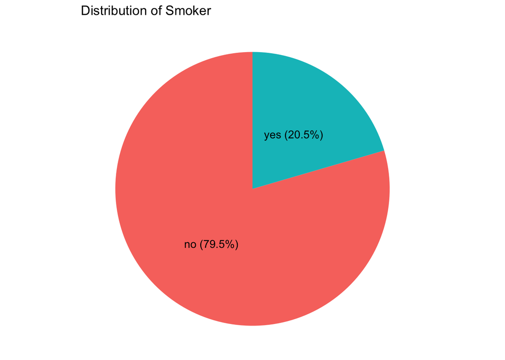

```r
smoker_data <- insurance %>%
  count(smoker) %>%
  mutate(perc = n / sum(n) * 100,
         label = paste0(smoker, " (", round(perc, 1), "%)"))

ggplot(smoker_data, aes(x = "", y = perc, fill = smoker)) +
  geom_bar(width = 1, stat = "identity") +
  coord_polar("y") +
  labs(title = "Distribution of Smoker", x = NULL, y = NULL) +
  theme_void() +
  geom_text(aes(label = label), position = position_stack(vjust = 0.5)) +
  theme(legend.position = "none")
```

## 1.4 Correalation between varibles

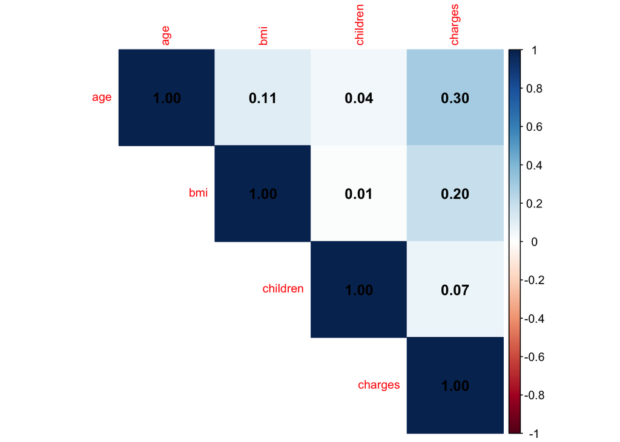

```r
num_vars <- insurance %>% select_if(is.numeric)
cor_matrix <- cor(num_vars)

corrplot(cor_matrix, method = "color", type = "upper", addCoef.col = "black", tl.cex = 0.8)
```

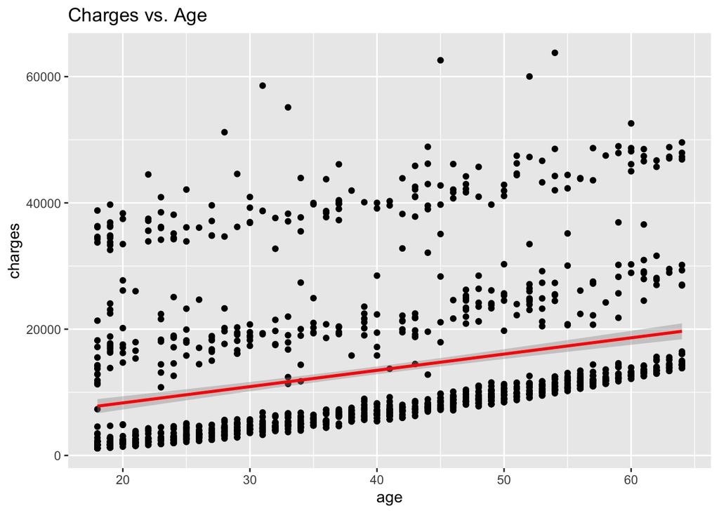

```r
ggplot(insurance, aes(x = age, y = charges)) + geom_point() + geom_smooth(method = "lm", color = "red") + ggtitle("Charges vs. Age")
```

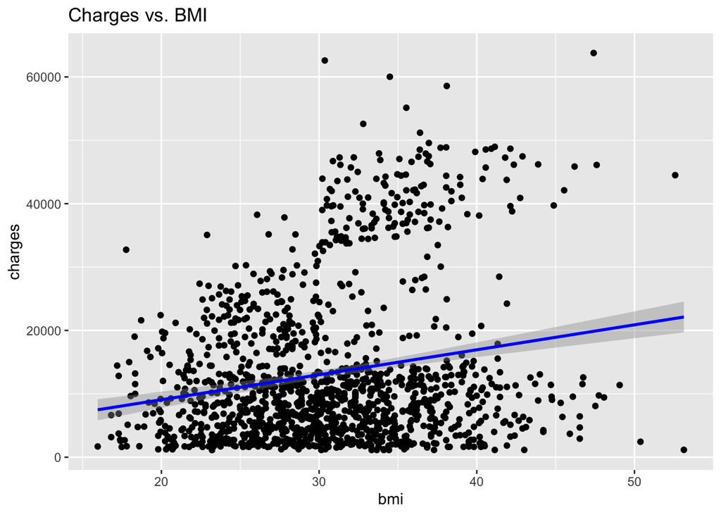

```r
ggplot(insurance, aes(x = bmi, y = charges)) + geom_point() + geom_smooth(method = "lm", color = "blue") + ggtitle("Charges vs. BMI")
```

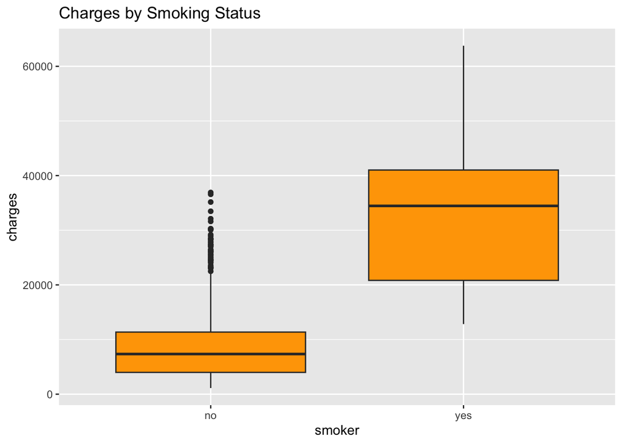

```r
ggplot(insurance, aes(x = smoker, y = charges)) + geom_boxplot(fill = "orange") + ggtitle("Charges by Smoking Status")
```

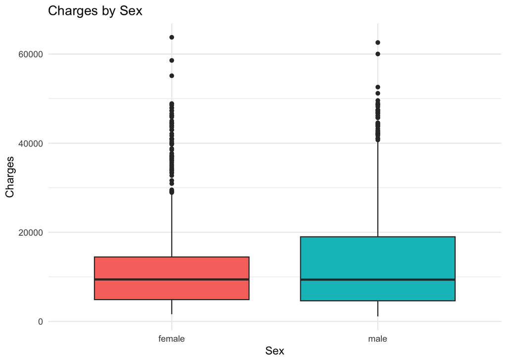

```r
ggplot(insurance, aes(x = sex, y = charges, fill = sex)) +
  geom_boxplot() +
  labs(title = "Charges by Sex", x = "Sex", y = "Charges") +
  theme_minimal() +
  theme(legend.position = "none")
```

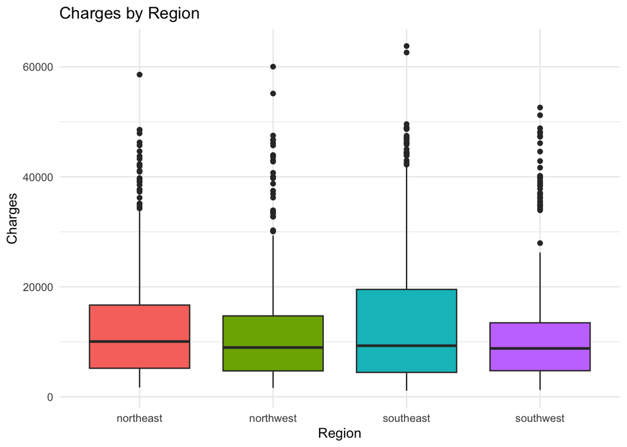

```r
ggplot(insurance, aes(x = region, y = charges, fill = region)) +
  geom_boxplot() +
  labs(title = "Charges by Region", x = "Region", y = "Charges") +
  theme_minimal() +
  theme(legend.position = "none")
```

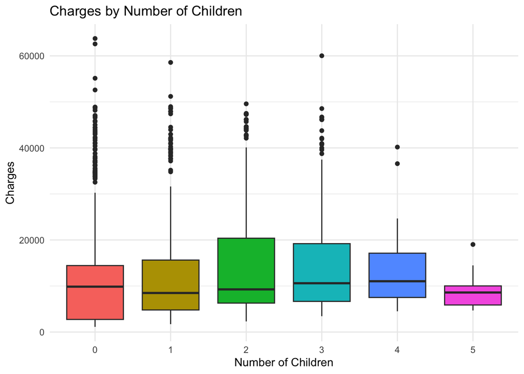

```r
ggplot(insurance, aes(x = as.factor(children), y = charges, fill = as.factor(children))) +
  geom_boxplot() +
  labs(title = "Charges by Number of Children", x = "Number of Children", y = "Charges") +
  theme_minimal() +
  theme(legend.position = "none")
```

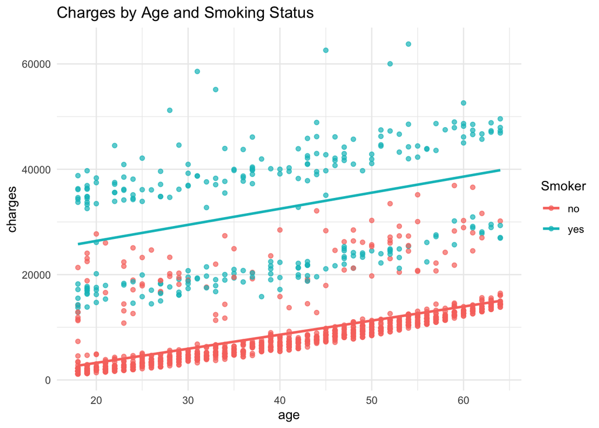

```r
# relationship between age/children/bmi/sex and charges for smokers and non-smokers
ggplot(insurance, aes(x = age, y = charges, color = as.factor(smoker))) +
  geom_point(alpha = 0.7) +
  geom_smooth(method = "lm", se = FALSE) +
  labs(color = "Smoker", title = "Charges by Age and Smoking Status") +
  theme_minimal()
```

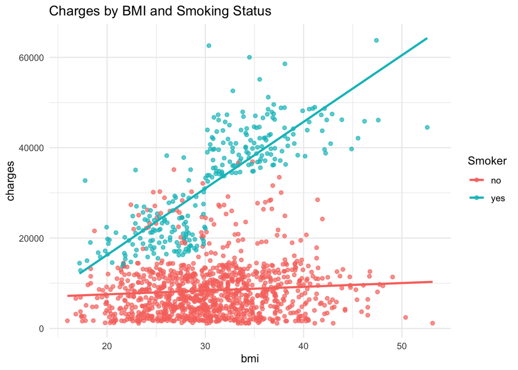

```r
ggplot(insurance, aes(x = bmi, y = charges, color = as.factor(smoker))) +
  geom_point(alpha = 0.7) +
  geom_smooth(method = "lm", se = FALSE) +
  labs(color = "Smoker", title = "Charges by BMI and Smoking Status") +
  theme_minimal()
```

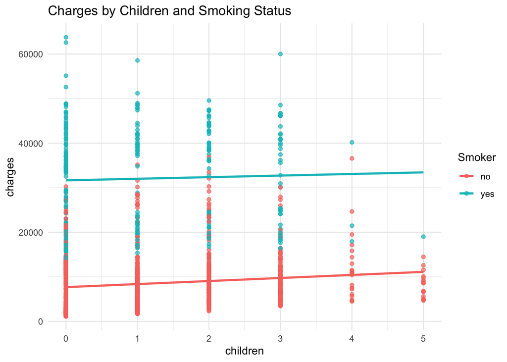

```r
ggplot(insurance, aes(x = children, y = charges, color = as.factor(smoker))) +
  geom_point(alpha = 0.7) +
  geom_smooth(method = "lm", se = FALSE) +
  labs(color = "Smoker", title = "Charges by Children and Smoking Status") +
  theme_minimal()
```

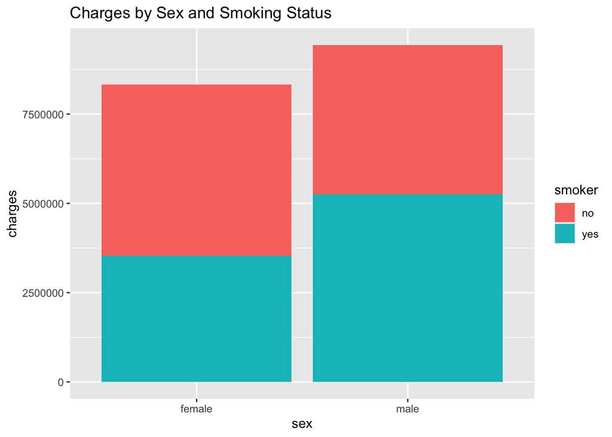

```r
ggplot(insurance, aes(x=sex, y=charges, fill=smoker)) +
  labs(color = "Smoker", title = "Charges by Sex and Smoking Status") +
  geom_bar(stat="identity")
```

# 2.Models

## 2.1 Feature engineering

```r
insurance_scaled <- insurance %>%
  mutate(
    sex = ifelse(sex == "male", 1, 0),
    smoker = ifelse(smoker == "yes", 1, 0),
    across(c(age, bmi, children, charges), scale)
  )


region_dummies <- model.matrix(~ region - 1, data = insurance) %>%
  as.data.frame()

insurance_scaled <- cbind(insurance_scaled, region_dummies) %>%
  as.data.frame() %>%
  dplyr::select(-region)

str(insurance_scaled)
```

```
## 'data.frame':    1338 obs. of  10 variables:
##  $ age            : num [1:1338, 1] -1.438 -1.509 -0.798 -0.442 -0.513 ...
##   ..- attr(*, "scaled:center")= num 39.2
##   ..- attr(*, "scaled:scale")= num 14
##  $ sex            : num  0 1 1 1 1 0 0 0 1 0 ...
##  $ bmi            : num [1:1338, 1] -0.453 0.509 0.383 -1.305 -0.292 ...
##   ..- attr(*, "scaled:center")= num 30.7
##   ..- attr(*, "scaled:scale")= num 6.1
##  $ children       : num [1:1338, 1] -0.9083 -0.0787 1.5803 -0.9083 -0.9083 ...
##   ..- attr(*, "scaled:center")= num 1.09
##   ..- attr(*, "scaled:scale")= num 1.21
##  $ smoker         : num  1 0 0 0 0 0 0 0 0 0 ...
##  $ charges        : num [1:1338, 1] 0.298 -0.953 -0.728 0.72 -0.777 ...
##   ..- attr(*, "scaled:center")= num 13270
##   ..- attr(*, "scaled:scale")= num 12110
##  $ regionnortheast: num  0 0 0 0 0 0 0 0 1 0 ...
##  $ regionnorthwest: num  0 0 0 1 1 0 0 1 0 1 ...
##  $ regionsoutheast: num  0 1 1 0 0 1 1 0 0 0 ...
##  $ regionsouthwest: num  1 0 0 0 0 0 0 0 0 0 ...
```

Why?

Lasso and Ridge regression methods are sensitive to the scale of predictors because they add penalties to the coefficients. Variables with larger scales (e.g., age vs. children) can disproportionately influence the model if not standardized. Standardization allows for easier comparison of coefficient magnitudes, as they all use the same scale.

## 2.2 Data preparation and splitting

```r
# Create response and predictors
response <- insurance_scaled$charges
predictors <- insurance_scaled %>% dplyr::select(-charges)
```

```r
# Split data into training and testing sets
set.seed(123)
trainIndex <- createDataPartition(response, p = 0.8, list = FALSE)
trainX <- predictors[trainIndex, ]
testX <- predictors[-trainIndex, ]
trainY <- response[trainIndex]
testY <- response[-trainIndex]
```

## 2.3 Linear Regression

```r
# Linear Regression Model
lm_model <- lm(trainY ~ ., data = as.data.frame(trainX))
lm_pred <- predict(lm_model, newdata = as.data.frame(testX))
lm_rmse <- sqrt(mean((lm_pred - testY)^2))
print(paste("Linear Regression RMSE:", round(lm_rmse, 3)))
```

```
## [1] "Linear Regression RMSE: 0.519"
```

```r
# summary(lm_model)
```

```r
# Print coefficients and intercept
lm_coef <- coef(lm_model)
print("Linear Regression Coefficients:")
```

```
## [1] "Linear Regression Coefficients:"
```

```r
print(lm_coef)
```

```
##     (Intercept)             age             sex             bmi        children
##    -0.439852849     0.286683540    -0.009650082     0.164962757     0.043555926
##          smoker regionnortheast regionnorthwest regionsoutheast regionsouthwest
##     2.001937116     0.086120081     0.043655226     0.005099853              NA
```

```r
# Calculate R-squared for the linear model
lm_r_squared <- summary(lm_model)$r.squared
print(paste("Linear Regression R-squared:", round(lm_r_squared, 3)))
```

```
## [1] "Linear Regression R-squared: 0.759"
```

```r
# Adjusted R-squared for completeness
lm_adj_r_squared <- summary(lm_model)$adj.r.squared
print(paste("Linear Regression Adjusted R-squared:", round(lm_adj_r_squared, 3)))
```

```
## [1] "Linear Regression Adjusted R-squared: 0.758"
```

### Checking assumptions

```r
# Residuals and fitted values
lm_fitted <- fitted(lm_model)  # Fitted values
lm_residuals <- resid(lm_model)  # Residuals
lm_std_residuals <- rstandard(lm_model)  # Standardized residuals
```

1.Residuals vs Fitted (Linearity and Homoscedasticity)

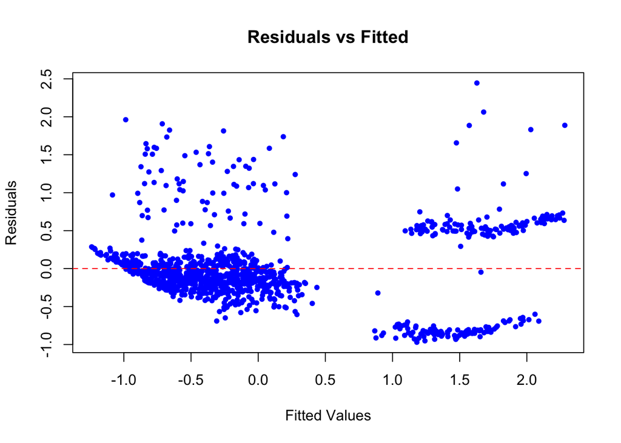

```r
plot(lm_fitted, lm_residuals,
     main = "Residuals vs Fitted",
     xlab = "Fitted Values",
     ylab = "Residuals",
     pch = 20, col = "blue")
abline(h = 0, lty = 2, col = "red")
```

2. Normal Q-Q Plot (Normality of Residuals)

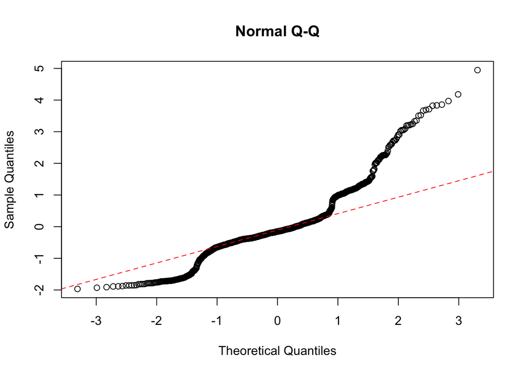

```r
qqnorm(lm_std_residuals, main = "Normal Q-Q")
qqline(lm_std_residuals, col = "red", lty = 2)
```

3. Scale-Location Plot (Homoscedasticity)

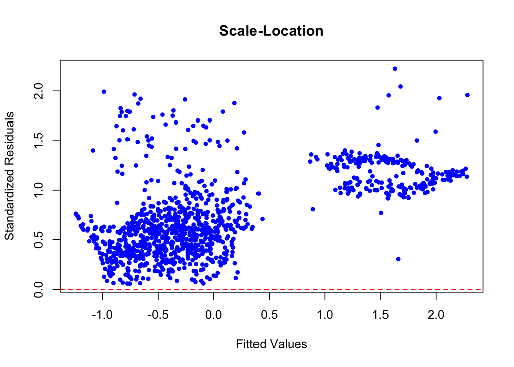

```r
plot(lm_fitted, sqrt(abs(lm_std_residuals)),
     main = "Scale-Location",
     xlab = "Fitted Values",
     ylab = "Standardized Residuals",
     pch = 20, col = "blue")
abline(h = 0, lty = 2, col = "red")
```

4. Residuals vs Leverage (Influential Points)

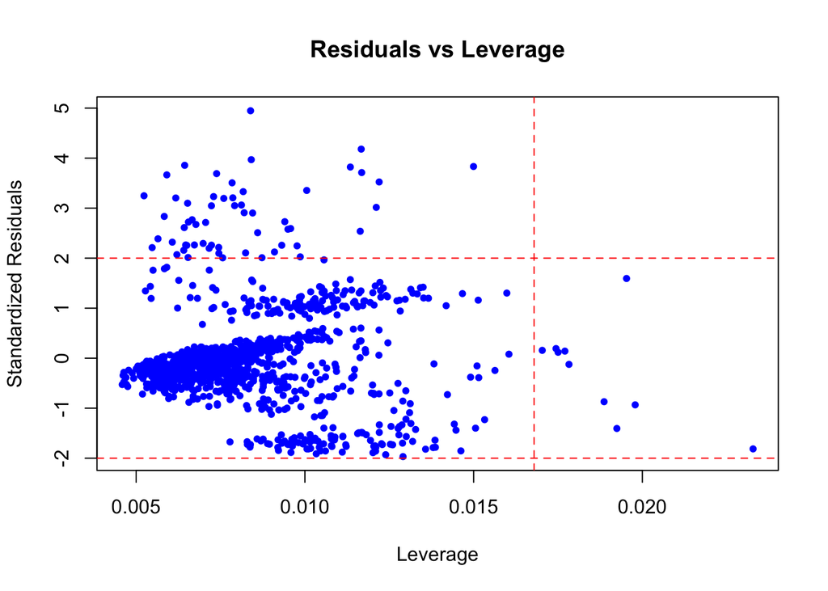

```r
plot(hatvalues(lm_model), lm_std_residuals,
     main = "Residuals vs Leverage",
     xlab = "Leverage",
     ylab = "Standardized Residuals",
     pch = 20, col = "blue")
abline(h = c(-2, 2), col = "red", lty = 2)  # Outlier thresholds
abline(v = 2 * mean(hatvalues(lm_model)), col = "red", lty = 2)  # High leverage threshold
```

```r
dwtest(lm_model)
```

```
##
##  Durbin-Watson test
##
## data:  lm_model
## DW = 2.057, p-value = 0.5265
## alternative hypothesis: true autocorrelation is greater than 0
```

## 2.4 Lasso Regression

Lasso regression performs feature selection by setting some coefficients to exactly zero, leaving only the most important features in the model.

```r
# Lasso Regression
trainX <- as.matrix(trainX)
testX <- as.matrix(testX)

colnames(testX) <- colnames(trainX)

lasso_model <- cv.glmnet(trainX, trainY, alpha = 1)
lasso_pred <- predict(lasso_model, s = "lambda.min", newx = testX)
lasso_rmse <- sqrt(mean((lasso_pred - testY)^2))
print(paste("Lasso Regression RMSE:", round(lasso_rmse, 3)))
```

```
## [1] "Lasso Regression RMSE: 0.52"
```

```r
# Extract coefficients for Lasso
lasso_coef <- coef(lasso_model, s = "lambda.min")
print("Lasso Coefficients:")
```

```
## [1] "Lasso Coefficients:"
```

```r
print(lasso_coef)
```

```
## 10 x 1 sparse Matrix of class "dgCMatrix"
##                           s1
## (Intercept)     -0.423787812
## age              0.282128970
## sex              .
## bmi              0.156692841
## children         0.038106133
## smoker           1.985617668
## regionnortheast  0.055763527
## regionnorthwest  0.013723239
## regionsoutheast  .
## regionsouthwest -0.007091423
```

```r
# Print the best lambda for Lasso
lasso_lambda_min <- lasso_model$lambda.min
print(paste("Lasso Lambda (Best Penalty):", round(lasso_lambda_min, 5)))
```

```
## [1] "Lasso Lambda (Best Penalty): 0.00582"
```

```r
# Calculate R-squared for Lasso
lasso_r_squared <- 1 - sum((lasso_pred - testY)^2) / sum((testY - mean(testY))^2)
print(paste("Lasso R-squared:", round(lasso_r_squared, 3)))
```

```
## [1] "Lasso R-squared: 0.71"
```

### Feature Importance

The magnitude of the coefficients reflects the importance of each feature in predicting the target variable. Larger absolute values indicate a stronger influence on the prediction.

In Lasso and Ridge regression, the coefficients are regularized, which helps to shrink less important features toward zero. Features with larger coefficients are considered more important.

```r
lasso_coef <- coef(lasso_model, s = "lambda.min")
lasso_coef_df <- data.frame(
  Feature = rownames(lasso_coef),
  Coefficient = as.vector(lasso_coef)
)
lasso_coef_df <- lasso_coef_df[-1, ]
lasso_coef_df$Importance <- abs(lasso_coef_df$Coefficient)

lasso_coef_df <- lasso_coef_df[order(-lasso_coef_df$Importance), ]

print("Lasso Feature Importance:")
```

```
## [1] "Lasso Feature Importance:"
```

```r
print(lasso_coef_df)
```

```
##            Feature  Coefficient  Importance
## 6           smoker  1.985617668 1.985617668
## 2              age  0.282128970 0.282128970
## 4              bmi  0.156692841 0.156692841
## 7  regionnortheast  0.055763527 0.055763527
## 5         children  0.038106133 0.038106133
## 8  regionnorthwest  0.013723239 0.013723239
## 10 regionsouthwest -0.007091423 0.007091423
## 3              sex  0.000000000 0.000000000
## 9  regionsoutheast  0.000000000 0.000000000
```

## 2.5 Ridge Regression

Ridge regression shrinks coefficients but keeps all features in the model, with the magnitude of the coefficients indicating their relative importance.

```r
# Ridge Regression
ridge_model <- cv.glmnet(trainX, trainY, alpha = 0)
ridge_pred <- predict(ridge_model, s = "lambda.min", newx = testX)
ridge_rmse <- sqrt(mean((ridge_pred - testY)^2))
```

```r
# Extract coefficients for Ridge
ridge_coef <- coef(ridge_model, s = "lambda.min")
print("Ridge Coefficients:")
```

```
## [1] "Ridge Coefficients:"
```

```r
print(ridge_coef)
```

```
## 10 x 1 sparse Matrix of class "dgCMatrix"
##                           s1
## (Intercept)     -0.380909219
## age              0.265818518
## sex             -0.000286307
## bmi              0.153558294
## children         0.041336555
## smoker           1.851236169
## regionnortheast  0.046776598
## regionnorthwest  0.006294199
## regionsoutheast -0.016383825
## regionsouthwest -0.033489280
```

```r
# Print the best lambda for Ridge
ridge_lambda_min <- ridge_model$lambda.min
print(paste("Ridge Lambda (Best Penalty):", round(ridge_lambda_min, 5)))
```

```
## [1] "Ridge Lambda (Best Penalty): 0.08054"
```

```r
# Calculate R-squared for Ridge
ridge_r_squared <- 1 - sum((ridge_pred - testY)^2) / sum((testY - mean(testY))^2)
print(paste("Ridge R-squared:", round(ridge_r_squared, 3)))
```

```
## [1] "Ridge R-squared: 0.712"
```

### Feature Importance

```r
ridge_coef <- coef(ridge_model, s = "lambda.min")
ridge_coef_df <- data.frame(
  Feature = rownames(ridge_coef),
  Coefficient = as.vector(ridge_coef)
)
ridge_coef_df <- ridge_coef_df[-1, ]
ridge_coef_df$Importance <- abs(ridge_coef_df$Coefficient)

ridge_coef_df <- ridge_coef_df[order(-ridge_coef_df$Importance), ]

print("Ridge Feature Importance:")
```

```
## [1] "Ridge Feature Importance:"
```

```r
print(ridge_coef_df)
```

```
##            Feature  Coefficient  Importance
## 6           smoker  1.851236169 1.851236169
## 2              age  0.265818518 0.265818518
## 4              bmi  0.153558294 0.153558294
## 7  regionnortheast  0.046776598 0.046776598
## 5         children  0.041336555 0.041336555
## 10 regionsouthwest -0.033489280 0.033489280
## 9  regionsoutheast -0.016383825 0.016383825
## 8  regionnorthwest  0.006294199 0.006294199
## 3              sex -0.000286307 0.000286307
```

## 2.6 Compare model performance

```r
model_performance <- data.frame(
  Model = c("Linear Regression", "Lasso Regression", "Ridge Regression"),
  RMSE = c(lm_rmse, lasso_rmse, ridge_rmse)
)
model_performance
```

```
##               Model      RMSE
## 1 Linear Regression 0.5193958
## 2  Lasso Regression 0.5203408
## 3  Ridge Regression 0.5186231
```

# 3.Hypothesis Test

Conduct a hypothesis test to check the effect of smoking on insurance charges.

## 3.1 ANOVA

```r
linear_model <- lm(charges ~ smoker, data = insurance)
summary(lm(charges ~ smoker, data = insurance))
```

```
##
## Call:
## lm(formula = charges ~ smoker, data = insurance)
##
## Residuals:
##    Min     1Q Median     3Q    Max
## -19221  -5042   -919   3705  31720
##
## Coefficients:
##             Estimate Std. Error t value Pr(>|t|)
## (Intercept)   8434.3      229.0   36.83   <2e-16 ***
## smokeryes    23616.0      506.1   46.66   <2e-16 ***
## ---
## Signif. codes:  0 '***' 0.001 '**' 0.01 '*' 0.05 '.' 0.1 ' ' 1
##
## Residual standard error: 7470 on 1336 degrees of freedom
## Multiple R-squared:  0.6198, Adjusted R-squared:  0.6195
## F-statistic:  2178 on 1 and 1336 DF,  p-value: < 2.2e-16
```

```r
anova(linear_model)
```

```
## Analysis of Variance Table
##
## Response: charges
##             Df     Sum Sq    Mean Sq F value    Pr(>F)
## smoker       1 1.2152e+11 1.2152e+11  2177.6 < 2.2e-16 ***
## Residuals 1336 7.4554e+10 5.5804e+07
## ---
## Signif. codes:  0 '***' 0.001 '**' 0.01 '*' 0.05 '.' 0.1 ' ' 1
```

## 3.2 t test

```r
t_test_result <- t.test(charges ~ smoker, data = insurance)
t_test_result
```

```
##
##  Welch Two Sample t-test
##
## data:  charges by smoker
## t = -32.752, df = 311.85, p-value < 2.2e-16
## alternative hypothesis: true difference in means between group no and group yes is not equal to 0
## 95 percent confidence interval:
##  -25034.71 -22197.21
## sample estimates:
##  mean in group no mean in group yes
##          8434.268         32050.232
```